# 분석용 데이터 구축 & 탐색적 데이터 분석 평가

# 평가 개요

- 훈련과정명 : Python, JAVA 기반 AI 활용 소프트웨어 개발 및 응용 과정
- 교과목 : 분석용 데이터 구축 & 탐색적 데이터 분석
- 평가유형 : 사례연구
- 평가일시 : 2022년 12월 23일
- 평가자 : 정지훈 강사
- 학생명 : 김동범

# 분석용 데이터 구축 사례연구

## 평가 문항 1. 데이터 정제하기 (10점)

- 다음 자료형에 따른 데이터들을 벡터 형태의 변수로 구성해 보시오.

| 자료형 | 변수명 | 데이터 값 |
| --- | --- | --- |
| 문자형 | ID | 1, 2, 3, 4, 5, 6, 7, 8, 9 |
| 문자형 | NAME | 최유진, 마시로, 샤오팅, 김채현, 김다연, 히카루, 바히에, 서영은, 강예서 |
| 숫자형 | AGE | 25, 22, 22, 20, 19, 18, 17, 17, 16 |
| 문자형 | NATION | 한국, 일본, 중국, 한국, 한국, 일본, 한국/미국, 한국, 한국 |
| 문자형 | POSITION | 리더, 부리더, 메인댄서, 메인보컬, 메인댄서,메인래퍼, 서브보컬, 메인보컬, 서브댄서 |

```r
ID = c(1, 2, 3, 4, 5, 6, 7, 8, 9)
NAME = c("최유진", "마시로", "샤오팅", "김채형", "김다연", "히카루", "바히에", "서영은", "강예서")
AGE = c(25, 22, 22, 20, 19, 18, 17, 17, 16)
NATION = c("한국", "일본", "중국", "한국", "한국", "일본", "한국/미국", "한국", "한국")
POSITION = c("리더", "부리더", "메인댄서", "메인보컬", "메인댄서", "메인래퍼", "서브보컬", "메인보컬", "서브댄서")
```

## 평가 문항 2. 데이터 검증하기 (10점)

- 데이터 프레임 함수와 앞선 문항에서 구성한 `ID`, `NAME`, `AGE`, `NATION`, `POSITION` 변수를 사용하여 `kepler` 데이터 세트를 테이블로 만들고 데이터를 파악 할 수 있는 함수 4가지를 통해 확인하는 코드를 작성하시오.
- 먼저, kepler 데이터 셋트를 만드세요.

```r
kepler = data.frame(
  "ID"       = ID,
  "NAME"     = NAME,
  "AGE"      = AGE,
  "NATION"   = NATION,
  "POSITION" = POSITION
)
```

- 함수 1 : 변수의 속성이 문자형인지, 숫자형인지 확인할 때 쓰는 함수

```r
str(kepler)
```

```
## 'data.frame':    9 obs. of  5 variables:
##  $ ID      : num  1 2 3 4 5 6 7 8 9
##  $ NAME    : chr  "최유진" "마시로" "샤오팅" "김채형" ...
##  $ AGE     : num  25 22 22 20 19 18 17 17 16
##  $ NATION  : chr  "한국" "일본" "중국" "한국" ...
##  $ POSITION: chr  "리더" "부리더" "메인댄서" "메인보컬" ...
```

- 함수 2: 데이터 세트가 몇 행 몇 열로 구성되어 있는지 확인할 때 사용

```r
dim(kepler)
```

```
## [1] 9 5
```

- 함수 3: 데이터 세트에 포함된 변수명, 데이터 세트의 열 제목만 따로 뽑아서 확인할 때 사용

```r
ls(kepler)
```

```
## [1] "AGE"      "ID"       "NAME"     "NATION"   "POSITION"
```

- 함수 4: 데이터 세트의 상위 6개의 데이터만 추출할 때 사용

```r
head(kepler)
```

|  | ID | NAME | AGE | NATION | POSITION |
| --- | --- | --- | --- | --- | --- |
| 1 | 1 | 최유진 | 25 | 한국 | 리더 |
| 2 | 2 | 마시로 | 22 | 일본 | 부리더 |
| 3 | 3 | 샤오팅 | 22 | 중국 | 메인댄서 |
| 4 | 4 | 김채형 | 20 | 한국 | 메인보컬 |
| 5 | 5 | 김다연 | 19 | 한국 | 메인댄서 |
| 6 | 6 | 히카루 | 18 | 일본 | 메인래퍼 |

## 평가 문항 3. 데이터 정제하기 (10점)

- 앞서 만든 kepler 데이터 세트를 엑셀 파일(kepler.xlsx), 텍스트 파일(kepler.txt), CSV 파일(kepler.csv)로 저장하는 코드를 작성하시오. 이 때 엑설로 저장하는 패키지를 설치하고 로드하는 코드도 함께 작성하시오.
- 엑셀로 저장하는 패키지 설치 코드 작성

```
install.packages("writexl")
install.packages("readxl")
```

- 데이터 세트를 csv 파일로 저장한다.
  - 파일명 : `kepler.csv`

```r
write.csv(kepler, file = 'kepler.csv')
```

- 데이터 세트를 엑셀 파일로 저장한다.
  - 파일명 : `kepler.xlsx`

```r
library(writexl)
write_xlsx(kepler, path = 'kepler.xlsx')
```

## 평가 문항 4. 데이터 검증하기 (10점)

- 앞서 생성한 엑셀 파일`(kepler.xlsx)`을 `kepler1` 변수에 저장하고 데이터를 확인하는 코드를 작성하시오. 앞서 생성한 `csv 파일(kepler.csv)`을 `kepler2` 변수에 저장하는 데이터를 확인하는 코드를 작성하시요. 이때 엑설에서 파일을 읽어오는 패키지를 설치하고 로드하는 코드도 함께 작성하시오.
  - 데이터 확인 시, str() 함수를 사용한다.
- 엑셀 파일 불러오기

```r
library(readxl)

kepler1 = read_xlsx(path = "kepler.xlsx")
str(kepler1)
```

```
## tibble [9 x 5] (S3: tbl_df/tbl/data.frame)
##  $ ID      : num [1:9] 1 2 3 4 5 6 7 8 9
##  $ NAME    : chr [1:9] "최유진" "마시로" "샤오팅" "김채형" ...
##  $ AGE     : num [1:9] 25 22 22 20 19 18 17 17 16
##  $ NATION  : chr [1:9] "한국" "일본" "중국" "한국" ...
##  $ POSITION: chr [1:9] "리더" "부리더" "메인댄서" "메인보컬" ...
```

- csv 파일 불러오기

```r
kepler2 = read.csv(file = "kepler.csv")
str(kepler2)
```

```
## 'data.frame':    9 obs. of  6 variables:
##  $ X       : int  1 2 3 4 5 6 7 8 9
##  $ ID      : int  1 2 3 4 5 6 7 8 9
##  $ NAME    : chr  "최유진" "마시로" "샤오팅" "김채형" ...
##  $ AGE     : int  25 22 22 20 19 18 17 17 16
##  $ NATION  : chr  "한국" "일본" "중국" "한국" ...
##  $ POSITION: chr  "리더" "부리더" "메인댄서" "메인보컬" ...
```

# 탐색적 데이터 분석 사례연구

## 평가 문항 5. 데이터 정제하기 (10점)

- 앞서 저장한 kepler1 데이터 세트의 NATION 변수명을 “출생지“ 으로 변경하는 코드를 작성하고 result 변수로 저장하세요.

```r
library(dplyr)
result = kepler1 %>% rename("출생지" = "NATION")
str(result)
```

```
## tibble [9 x 5] (S3: tbl_df/tbl/data.frame)
##  $ ID      : num [1:9] 1 2 3 4 5 6 7 8 9
##  $ NAME    : chr [1:9] "최유진" "마시로" "샤오팅" "김채형" ...
##  $ AGE     : num [1:9] 25 22 22 20 19 18 17 17 16
##  $ 출생지  : chr [1:9] "한국" "일본" "중국" "한국" ...
##  $ POSITION: chr [1:9] "리더" "부리더" "메인댄서" "메인보컬" ...
```

## 평가 문항 6. 데이터 분포 분석하기 (30점)

- 아래 조건을 만족하는 코드를 작성하세요.
  - 임의의 변수로 저장하여 결과를 표시해도 좋습니다.
- kepler1 데이터 세트에서 NAME과 AGE 변수만 추출하여 표시하는 코드를 작성하시오. [5]

```r
kepler1 %>% select(NAME, AGE)
```

| NAME | AGE |
| --- | --- |
| 최유진 | 25 |
| 마시로 | 22 |
| 샤오팅 | 22 |
| 김채형 | 20 |
| 김다연 | 19 |
| 히카루 | 18 |
| 바히에 | 17 |
| 서영은 | 17 |
| 강예서 | 16 |

- kepler1 데이터 세트에서 “출생지”가 일본인 멤버를 추출하는 코드를 작성하시오.[5]

```r
kepler1 %>% filter(NATION=='일본')
```

| ID | NAME | AGE | NATION | POSITION |
| --- | --- | --- | --- | --- |
| 2 | 마시로 | 22 | 일본 | 부리더 |
| 6 | 히카루 | 18 | 일본 | 메인래퍼 |

- kepler1 데이터 세트에서 “POSITION”이 메인보컬이고 “나이”가 20살 이하인 맴버를 선별하여 표시하는 코드를 작성하시오.[10]

```r
kepler1 %>% filter(POSITION=='메인보컬'& AGE<=20)
```

| ID | NAME | AGE | NATION | POSITION |
| --- | --- | --- | --- | --- |
| 4 | 김채형 | 20 | 한국 | 메인보컬 |
| 8 | 서영은 | 17 | 한국 | 메인보컬 |

- kepler1 데이터 세트에서 ggplot2 라이브러리를 활용하여 AGE에 대한 히스토그램 코드를 작성하시오.[10]

```r
library(ggplot2)
kepler1
```

| ID | NAME | AGE | NATION | POSITION |
| --- | --- | --- | --- | --- |
| 1 | 최유진 | 25 | 한국 | 리더 |
| 2 | 마시로 | 22 | 일본 | 부리더 |
| 3 | 샤오팅 | 22 | 중국 | 메인댄서 |
| 4 | 김채형 | 20 | 한국 | 메인보컬 |
| 5 | 김다연 | 19 | 한국 | 메인댄서 |
| 6 | 히카루 | 18 | 일본 | 메인래퍼 |
| 7 | 바히에 | 17 | 한국/미국 | 서브보컬 |
| 8 | 서영은 | 17 | 한국 | 메인보컬 |
| 9 | 강예서 | 16 | 한국 | 서브댄서 |

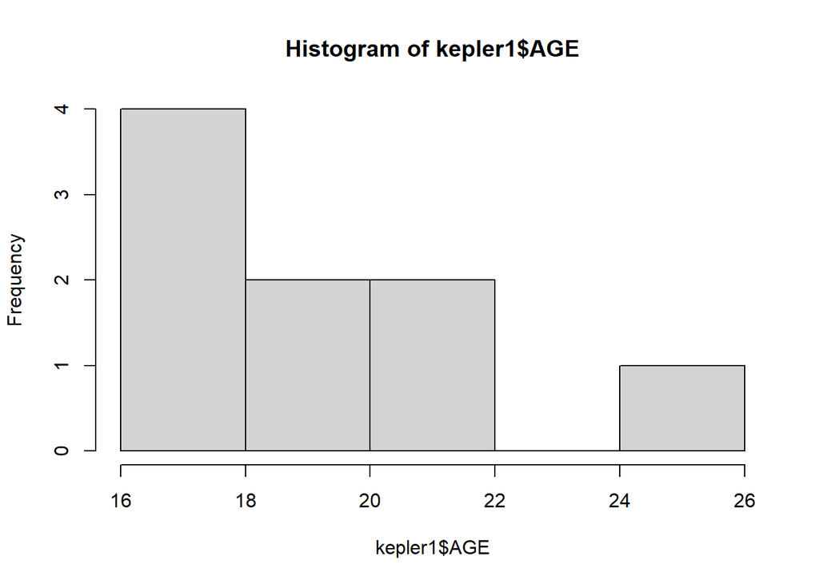

```r
hist(kepler1$AGE)
```

## 평가 문항 7. 변수간 관계확인하기 (20점)

- 아래 조건을 만족하는 코드를 작성하세요.
- R에서 제공하는 mpg 데이터셋을 불러온 후, cty 기준으로 내림차순으로 정렬한 후 상위 6개의 데이터만 추출한다.[5]

```r
data("mpg", package = "ggplot2")

mpg %>%
  arrange(desc(cty)) %>%
  head(n = 6)
```

| manufacturer | model | displ | year | cyl | trans | drv | cty | hwy | fl | class |
| --- | --- | --- | --- | --- | --- | --- | --- | --- | --- | --- |
| volkswagen | new beetle | 1.9 | 1999 | 4 | manual(m5) | f | 35 | 44 | d | subcompact |
| volkswagen | jetta | 1.9 | 1999 | 4 | manual(m5) | f | 33 | 44 | d | compact |
| volkswagen | new beetle | 1.9 | 1999 | 4 | auto(l4) | f | 29 | 41 | d | subcompact |
| honda | civic | 1.6 | 1999 | 4 | manual(m5) | f | 28 | 33 | r | subcompact |
| toyota | corolla | 1.8 | 2008 | 4 | manual(m5) | f | 28 | 37 | r | compact |
| honda | civic | 1.8 | 2008 | 4 | manual(m5) | f | 26 | 34 | r | subcompact |

- mpg 데이터셋에는 class 변수명의 값은 7개의 값이 존재한다. 각 클래스별 평균 cty를 구하고, 내림차순으로 졍렬한다. 이 때, 결과는 임의의 변수로 저장한다.[5]

```r
mp = mpg %>% group_by(class) %>%
  summarise(avg = mean(cty)) %>%
    arrange(desc(avg))
mp
```

| class | avg |
| --- | --- |
| subcompact | 20.37143 |
| compact | 20.12766 |
| midsize | 18.75610 |
| minivan | 15.81818 |
| 2seater | 15.40000 |
| suv | 13.50000 |
| pickup | 13.00000 |

- 저장된 데이터셋을 활용하여 막대그래프 코드를 작성한다.[10]

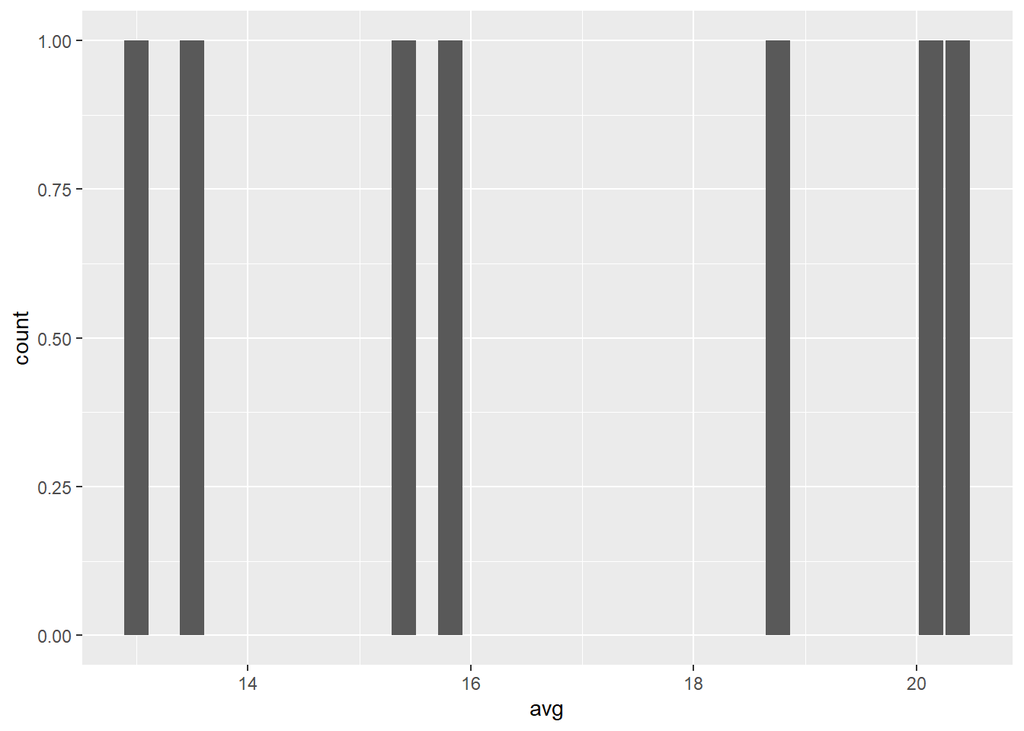

```r
ggplot(mp, aes(avg)) + geom_bar()
```